# TP5 - Intégrales Impropres

- $m_1$ : CLARY Emilie
- $m_2$ : CUVELIER Cyril
- $m_3$ : VAN BOXEM Rémi

## Exercice 1

Considérons $$ I := \int_0^{+\infty} \frac{sin (x)}{x}dx$$

### Question 2

Porter sur un même graphe les fonctions $ x \to \frac{sin (x)}{x}$ et $ X \to F(X)$ et discuter de ce que vous pouvez conjecturer par rapport à la convergence de l’intégrale impropre.

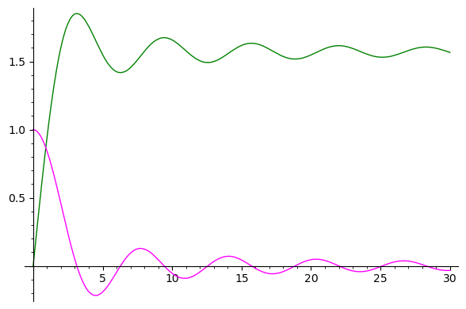

```python
var('x')
f(x) = sin(x)/x


def F(X):
    return numerical_integral(sin(x)/x, 0, X)[0]


plot(F, x, 0, 30, color="green") + plot(f(x), x, 0, 30, color="magenta")
```

## Question 2

Pour cette intégrale impropre, on peut montrer que $ |R(X)| \leq \frac{2}{(n + 1)\pi}$ avec $ n = [\frac{X}{\pi}] \in \mathbb{N} $ Utiliser ceci pour obtenir une approximation de $I$ précise à $ 10^{-3} $ près. Votre réponse est-elle cohérente avec vos observations à la question précédente ? Reconnaissez-vous cette valeur ?

$$\frac{2}{(n + 1)\pi} = 10^{-3}$$$$\frac{2}{\pi} = (n+1)\times 10^-3 $$$$n+1 = \frac{2 \times 10^3}{\pi} $$$$n = \frac{2 \times 10^3}{\pi}-1 $$

On en déduit que $n = \frac{2 \times 10^3}{\pi}-1 $

```python
n = ((2*(10 ^ 3))/(pi)) - 1
show(n)
```

\[\newcommand{\Bold}[1]{\mathbf{#1}}\frac{2000}{\pi} - 1\]

On en déduit que $n = \frac{2000}{\pi}-1$ Or : $n = [\frac{X}{\pi}]$. Ainsi on a $X = nx$ soit $x = 2000 - \pi$

```python
X = N(2000 - pi)
show("X = ", X)
# Ainsi, on peut calculer F(X)
show("F(X) = ", F(X))
```

\[\newcommand{\Bold}[1]{\mathbf{#1}}\verb|X|\phantom{\verb!x!}\verb|=| 1996.85840734641\]

\[\newcommand{\Bold}[1]{\mathbf{#1}}\verb|F(X)|\phantom{\verb!x!}\verb|=| 1.5706125412982406\]

On remarque que la valeur trouvée de $F(X)$ avec $X =2000 - \pi$ est proche de notre hypothèse de base, c'est à dire $F(x)$ tend vers $\frac{\pi}{2}$.

## Exercice 2

- Mêmes questions avec $$ I := \int_0^{+\infty} \frac{1 - e^{-x}}{1 + x^2}dx $$

On représente sur un graphique les deux fonctions.

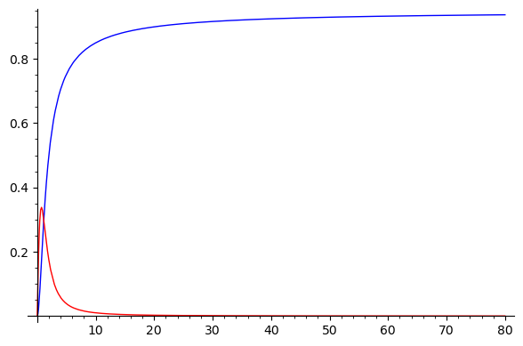

```python
def g(x):
    return (1-e ^ (-x))/(1+x ^ 2)


def G(X):
    return numerical_integral((1-e ^ (-x))/(1+x ^ 2), 0, X)[0]


plot(G, (0, 80), color='blue') + plot(g, (0, 80), color='red')
```

```python
reset()
t = var('t')
a = var('a')
t = 0
while((pi/2)-arctan(t) >= 10 ^ (-3)):
    t += 1

a = numerical_integral((1-exp(x) ^ (-x))/(1+x ^ 2), 0, t)[0]
show(numerical_approx(a, digits=4))
```

\[\newcommand{\Bold}[1]{\mathbf{#1}}0.8981\]

b) Nous admettons que $ |R(X)| \leq \int_0^{+\infty} \frac{1}{1 + x^2}dx = \frac{\pi}{2} - arctan X $

On cherche une approximation de $I$ précise à $\xi = 10^{-3}$ près.

On cherche à déterminer x. Nous savons que $|R(X|\leq \xi$. Or $|R(X)| \leq \frac{\pi}{2} - arctan X$. Donc nous allons trouver la valeur de X quand :

$$ \frac{\pi}{2} - arctan(x) = 10^{-3} $$$$ - arctan(x) = 10^{-3} - \frac{\pi}{2}$$$$ arctan(x) = \frac{\pi}{2} - 10^{-3}$$$$ x = tan(\frac{\pi}{2} - 10^{-3})$$

On fait une approximation numérique de x :

```python
X = tan((pi/2) - 10 ^ (-3))
show(numerical_approx(X))
```

\[\newcommand{\Bold}[1]{\mathbf{#1}}999.999666666693\]

Puis on calcule G(X)

```python
show(G(X))
```

\[\newcommand{\Bold}[1]{\mathbf{#1}}0.9483467025590832\]

Cette valeur est plutôt en accord avec notre conjecture.

- Cette fois avec $$ I := \int_0^{+\infty} e^{-x^{2}}dx, |R(X)| \le \frac{\sqrt{\pi}}{2}.e^{-X^{2}}$$

On représente sur un graphique les deux fonctions.

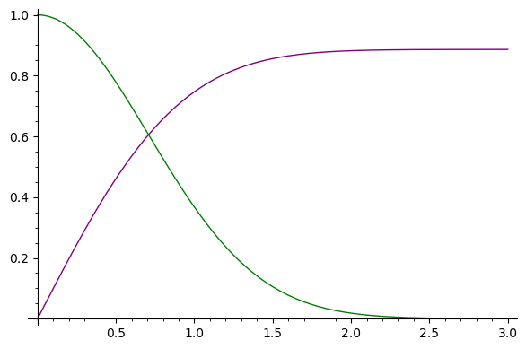

```python
def h(x):
    return e ^ (-x ^ (2))


def H(X):
    return numerical_integral(e ^ (-x ^ (2)), 0, X)[0]


plot(H, (0, 3), color='purple') + plot(h, (0, 3), color='green')
```

Lorsque $X$ tend vers $+\infty$, la courbe violette tend vers 0,9.

1. On admet que $ |R(X)| \leq \frac{\sqrt \pi}{2} e^{-X^{2}}$

Cherchons une approximation de $I$ précise à $\xi = 10^{-3} près$. Pour cela, nous déterminons X. Nous savons que $|R(X|\leq \xi$. Or $|R(X)| \leq \frac{\sqrt \pi}{2} e^{-X^{2}}$. Donc nous allons trouver la valeur de X quand $$ \frac{\sqrt \pi}{2} e^{-X^{2}} = 10^{-3} $$

$$ e^{-X^{2}} = \frac{2 _ 10^{-3}}{\sqrt \pi}$$$$ -X^{2} = ln(\frac{2 _ 10^{-3}}{\sqrt \pi})$$$$ -X^{2} = ln(2) + ln(10^{-3}) - ln(\sqrt \pi)$$$$ -X^{2} = ln(2) - 3 _ ln(10) - ln(\sqrt \pi)$$$$ X = \sqrt{- ln(2) + 3 _ ln(10) + ln(\sqrt \pi)}$$

On fait une approximation numérique de $X$ :

```python
X = sqrt(- ln(2) + 3 * ln(10) + ln(sqrt(pi)))
show(numerical_approx(X))
```

\[\newcommand{\Bold}[1]{\mathbf{#1}}2.60518195935464\]

Puis on veut calculer $H(X)$

```python
show(H(X))
```

\[\newcommand{\Bold}[1]{\mathbf{#1}}0.886023672211413\]

On est donc très proche du résultat trouvé avec la conjecture.

- Qu'en est-il de $$ I := \int_1^{+\infty} \frac{1}{x - e^{-x}}dx$$

On dessine sur un graphique la fonction et son intégrale.

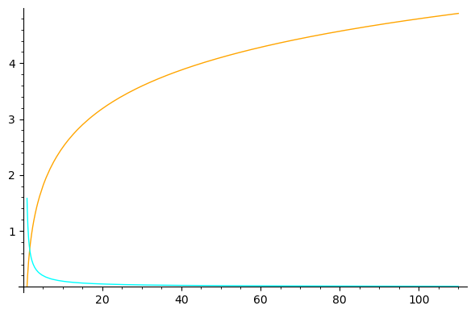

```python
def k(x):
    return 1/(x - e ^ (-x))


def K(X):
    return numerical_integral(1/(x - e ^ (-x)), 1, X)[0]


plot(K, (1, 110), color='orange') + plot(k, (1, 110), color='cyan')
```

L'intégrale K semble diverger lorsque $X$ tend vers $+\infty$

2) On peut remarquer que notre intégrale K est minorée par l'intégrale $ \int_1^{+\infty} \frac{1}{x}dx$

Graphiquement cela donne :

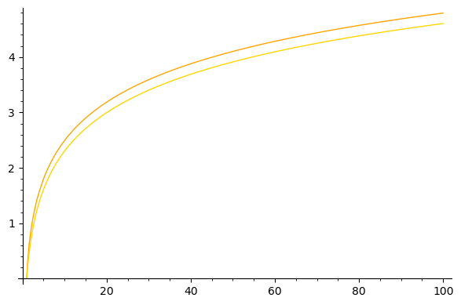

```python
def P(X):
    return numerical_integral(1/x, 1, X)[0]


plot(K, (1, 100), color='orange') + plot(P, (1, 100), color='gold')
```

Or $ \int_1^{+\infty} \frac{1}{x}dx$ une intégrale de Riemann avec $\alpha = 1$, donc cette intégrale diverge.

Étant minorée par une intégrale qui diverge, d'après le théorème de comparaison, l'intégrale K diverge également.

## Discutez des ressemblances et différences entre ces quatre cas.

On a 3 cas convergents : $$ I := \int_0^{+\infty} \frac{1 - e^{-x}}{1 + x^2}dx $$ $$ I := \int_0^{+\infty} \frac{sin (x)}{x}dx$$ $$ I := \int_0^{+\infty} e^{-x^{2}}dx$$

Alors que $ I := \int_1^{+\infty} \frac{1}{x - e^{-x}}dx$ (le dernier cas) diverge.

De ce fait, les 3 premiers cas peuvent être bornés, approximés à un $\xi$ donné et nous pouvons calculer n et X.

## Exercice 3

Considérons la fonction, définie par une intégrale impropre (convergente n’est-ce pas ?) : $$ G(\alpha) := \int_0^{\infty} x^\alpha e^{-x} dx, \alpha \geq 0 $$.

Pour des petites valeurs de $\alpha$ (disons, $ 0 \le \alpha \le 10 $), on peut raisonnablement dire que : $$ G(\alpha) \approx \int_0^{40} x^\alpha e^{-x} dx $$

Utilisez cette approximation pour tracer le graphe de $G$ sur $ [0, 10]$. Reconnaissez-vous les valeurs prises par $G$ lorsque $\alpha$ est entier ?

On affiche les différentes valeurs de G demandées :

\[\newcommand{\Bold}[1]{\mathbf{#1}}\verb|G(| 0 \verb|)|\phantom{\verb!x!}\verb|=| 1.00000000000000\]

\[\newcommand{\Bold}[1]{\mathbf{#1}}\verb|G(| 1 \verb|)|\phantom{\verb!x!}\verb|=| 1.00000000000000\]

\[\newcommand{\Bold}[1]{\mathbf{#1}}\verb|G(| 2 \verb|)|\phantom{\verb!x!}\verb|=| 1.99999999999999\]

\[\newcommand{\Bold}[1]{\mathbf{#1}}\verb|G(| 3 \verb|)|\phantom{\verb!x!}\verb|=| 5.99999999999971\]

\[\newcommand{\Bold}[1]{\mathbf{#1}}\verb|G(| 4 \verb|)|\phantom{\verb!x!}\verb|=| 23.9999999999879\]

\[\newcommand{\Bold}[1]{\mathbf{#1}}\verb|G(| 5 \verb|)|\phantom{\verb!x!}\verb|=| 119.999999999505\]

\[\newcommand{\Bold}[1]{\mathbf{#1}}\verb|G(| 6 \verb|)|\phantom{\verb!x!}\verb|=| 719.999999979627\]

\[\newcommand{\Bold}[1]{\mathbf{#1}}\verb|G(| 7 \verb|)|\phantom{\verb!x!}\verb|=| 5039.99999916134\]

\[\newcommand{\Bold}[1]{\mathbf{#1}}\verb|G(| 8 \verb|)|\phantom{\verb!x!}\verb|=| 40319.9999654487\]

\[\newcommand{\Bold}[1]{\mathbf{#1}}\verb|G(| 9 \verb|)|\phantom{\verb!x!}\verb|=| 362879.998575358\]

\[\newcommand{\Bold}[1]{\mathbf{#1}}\verb|G(| 10 \verb|)|\phantom{\verb!x!}\verb|=| 3.62879994120635 \times 10^{6}\]

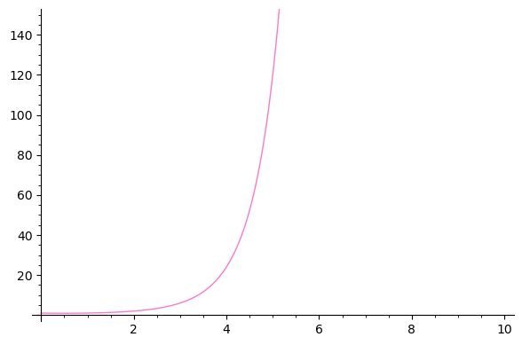

```python
reset()

t = var("t")
G = integral((x ^ t) * exp(-x), x, 0, 40)

for i in range(0, 11):
    show("G(", i, ") = ", numerical_approx(
        integral((x ^ i) * exp(-x), x, 0, 40)))
plot(G, xmin=0, xmax=10, ymin=0, ymax=150, color='#ff79C6')
```

Nous remarquons que les valeurs que prend $G$ lorsque t est entier sont semblables aux valeurs de $G(t-1) * t$.

```python
show(numerical_approx(G(3)*4))
show(numerical_approx(G(4)))
```

\[\newcommand{\Bold}[1]{\mathbf{#1}}23.9999999999988\]

\[\newcommand{\Bold}[1]{\mathbf{#1}}23.9999999999879\]